# MPDW P5

Salsabila Dwi Rahmi

2023-09-26

### Menyiapkan Packages

```r
library(ggplot2)
library(tsibble)
library(tseries)
library(MASS)
```

### Import data

```r
library(rio)
data <- import("https://raw.githubusercontent.com/salsabiladwi/PRAKMPDW/main/Pertemuan%205/data2.csv")
```

### Membuat set data menjadi time series

```r
data.ts <- ts(data$Close)
data.ts
```

```
## Time Series:
## Start = 1
## End = 118
## Frequency = 1
##   [1] 5625 5675 4940 4760 4830 4640 4810 5075 4780 5125 5100 5425 5300 5450 5450
##  [16] 5300 5100 5350 6150 6750 7450 7000 6950 6900 7025 6875 6725 6775 6750 6725
##  [31] 6750 7075 7100 7175 7500 7325 7700 7975 8000 7900 7950 8300 8225 8200 8425
##  [46] 8400 9350 9225 9225 8250 8775 9200 8950 8300 8175 8150 7850 7600 7275 7700
##  [61] 7850 8250 8525 8500 8300 8700 8800 8950 9000 8975 8775 8425 9000 9325 9275
##  [76] 9300 9200 9300 9750 9550 9800 9325 9225 8900 8675 9025 9550 9300 9525 9275
##  [91] 8900 8750 9025 9025 9625 9350 9375 9400 9475 9425 9250 9000 8825 8950 9050
## [106] 9225 9025 9025 9150 9075 8925 9050 8875 9000 9100 9050 9100 9175
```

### Membuat plot time series

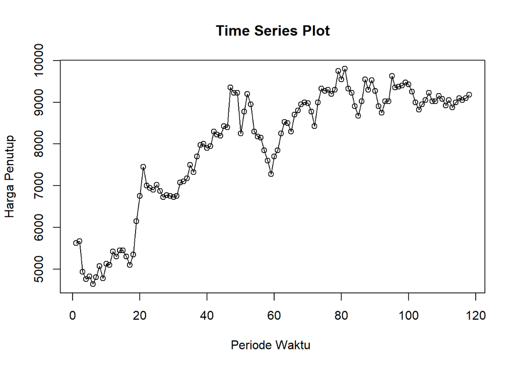

```r
ts.plot(data.ts, xlab="Periode Waktu ", ylab="Harga Penutup", main = "Time Series Plot")
points(data.ts)
```

```r
mean(data.ts)
```

```
## [1] 7986.314
```

Berdasarkan plot time series tersebut, terlihat bahwa data tidak stasioner dalam rataan, ditandai dengan adanya trend pada data dan tidak stasioner dalam ragam, ditandai dengan adanya perbedaan lebar pita pada plot

### Plot ACF

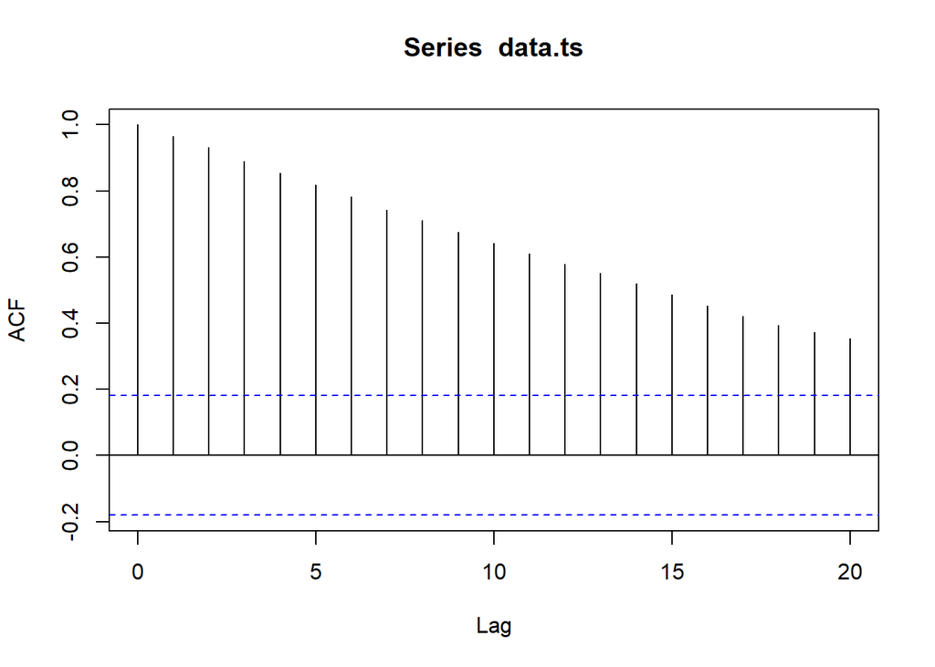

```r
acf(data.ts)
```

Berdasarkan plot ACF, terlihat bahwa plot ACF pada data tersebut cenderung *tails off slowly* yang artinya data cenderung tidak stasioner pada rataan.

### Uji ADF

```r
tseries::adf.test(data.ts)
```

```
##
##  Augmented Dickey-Fuller Test
##
## data:  data.ts
## Dickey-Fuller = -1.8099, Lag order = 4, p-value = 0.6555
## alternative hypothesis: stationary
```

$H_0$ : Data tidak stasioner dalam rataan

$H_1$ : Data stasioner dalam rataan

Berdasarkan uji ADF tersebut, didapat *p-value* sebesar 0.6555 yang lebih besar dari taraf nyata 5% sehingga terima $H_0$ dan menandakan bahwa data tidak stasioner dalam rataan. Hal ini sesuai dengan hasil eksplorasi menggunakan plot time series dan plot ACF.

### Plot Box-Cox

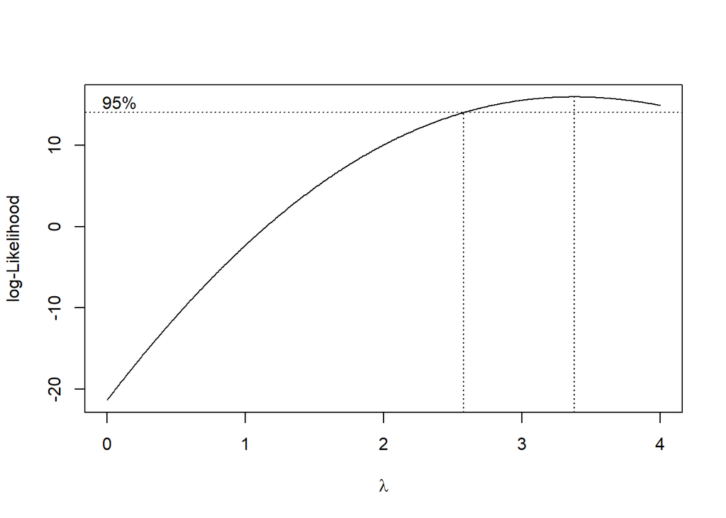

```r
index <- seq(1:118)
bc = boxcox(data.ts~index, lambda = seq(0,4,by=0.01))
```

```r
#Nilai Rounded Lambda
lambda <- bc$x[which.max(bc$y)]
lambda
```

```
## [1] 3.38
```

```r
#SK
bc$x[bc$y > max(bc$y) - 1/2 * qchisq(.95,1)]
```

```
##   [1] 2.58 2.59 2.60 2.61 2.62 2.63 2.64 2.65 2.66 2.67 2.68 2.69 2.70 2.71 2.72
##  [16] 2.73 2.74 2.75 2.76 2.77 2.78 2.79 2.80 2.81 2.82 2.83 2.84 2.85 2.86 2.87
##  [31] 2.88 2.89 2.90 2.91 2.92 2.93 2.94 2.95 2.96 2.97 2.98 2.99 3.00 3.01 3.02
##  [46] 3.03 3.04 3.05 3.06 3.07 3.08 3.09 3.10 3.11 3.12 3.13 3.14 3.15 3.16 3.17
##  [61] 3.18 3.19 3.20 3.21 3.22 3.23 3.24 3.25 3.26 3.27 3.28 3.29 3.30 3.31 3.32
##  [76] 3.33 3.34 3.35 3.36 3.37 3.38 3.39 3.40 3.41 3.42 3.43 3.44 3.45 3.46 3.47
##  [91] 3.48 3.49 3.50 3.51 3.52 3.53 3.54 3.55 3.56 3.57 3.58 3.59 3.60 3.61 3.62
## [106] 3.63 3.64 3.65 3.66 3.67 3.68 3.69 3.70 3.71 3.72 3.73 3.74 3.75 3.76 3.77
## [121] 3.78 3.79 3.80 3.81 3.82 3.83 3.84 3.85 3.86 3.87 3.88 3.89 3.90 3.91 3.92
## [136] 3.93 3.94 3.95 3.96 3.97 3.98 3.99 4.00
```

Gambar di atas menunjukkan nilai *rounded value* ($\lambda$) optimum sebesar **3.38** dan pada selang kepercayaan 95% nilai memiliki batas bawah **2.58** dan batas atas **4.00**. Selang tersebut tidak memuat nilai satu sehingga dapat dikatakan bahwa data yang di import tidak stasioner dalam ragam.

### Partisi Data

#### Bagian 1

```r
data.ts1 <- data.ts[1:50] |> ts()
mean(data.ts1)
```

```
## [1] 6697.2
```

```r
var(data.ts1)
```

```
## [1] 1837981
```

#### Plot Time Series

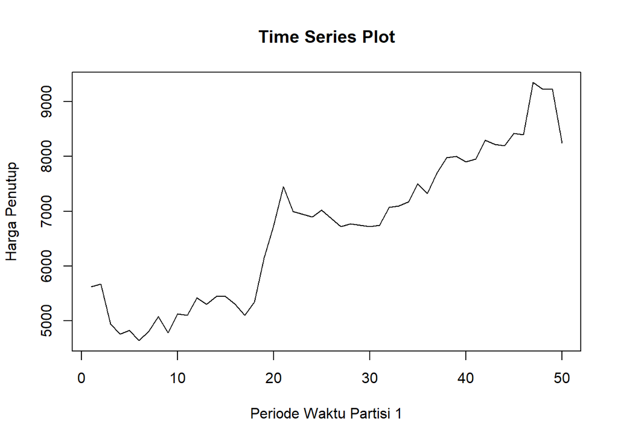

```r
ts.plot(data.ts1, xlab="Periode Waktu Partisi 1", ylab="Harga Penutup", main = "Time Series Plot")
```

Berdasarkan plot time series tersebut, terlihat bahwa data tidak stasioner dalam rataan karena masih terdapat tren pada data, namun cenderung stasioner dalam ragam karena memiliki lebar pita yang cenderung sama

#### Plot ACF

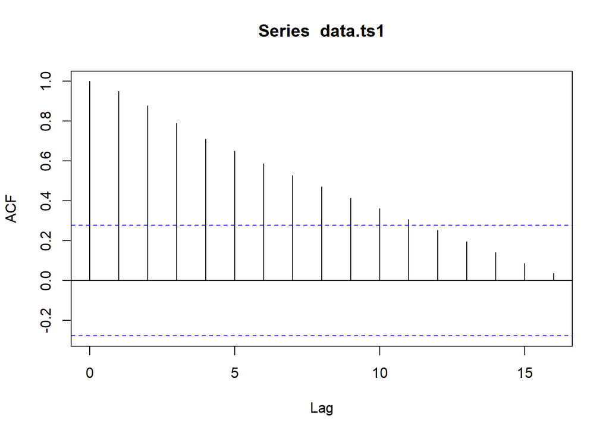

```r
acf(data.ts1)
```

Berdasarkan plot ACF, terlihat bahwa plot ACF pada data tersebut menurun secara perlahan (*tails off slowly*) yang menandakan data tidak stasioner dalam rataan

#### Uji ADF

```r
adf.test(data.ts1)
```

```
##
##  Augmented Dickey-Fuller Test
##
## data:  data.ts1
## Dickey-Fuller = -2.9438, Lag order = 3, p-value = 0.1957
## alternative hypothesis: stationary
```

$H_0$ : Data tidak stasioner dalam rataan

$H_1$ : Data stasioner dalam rataan

Berdasarkan uji ADF tersebut, didapat *p-value* sebesar 0.1957 yang lebih besar dari taraf nyata 5% dan menandakan bahwa data tidak stasioner dalam rataan. Hal ini sesuai dengan hasil eksplorasi menggunakan plot time series dan plot ACF

#### Bagian 2

```r
data.ts2 <- data.ts[51:118] |> ts()
mean(data.ts2)
```

```
## [1] 8934.191
```

```r
var(data.ts2)
```

```
## [1] 260837.8
```

#### Plot Time Series

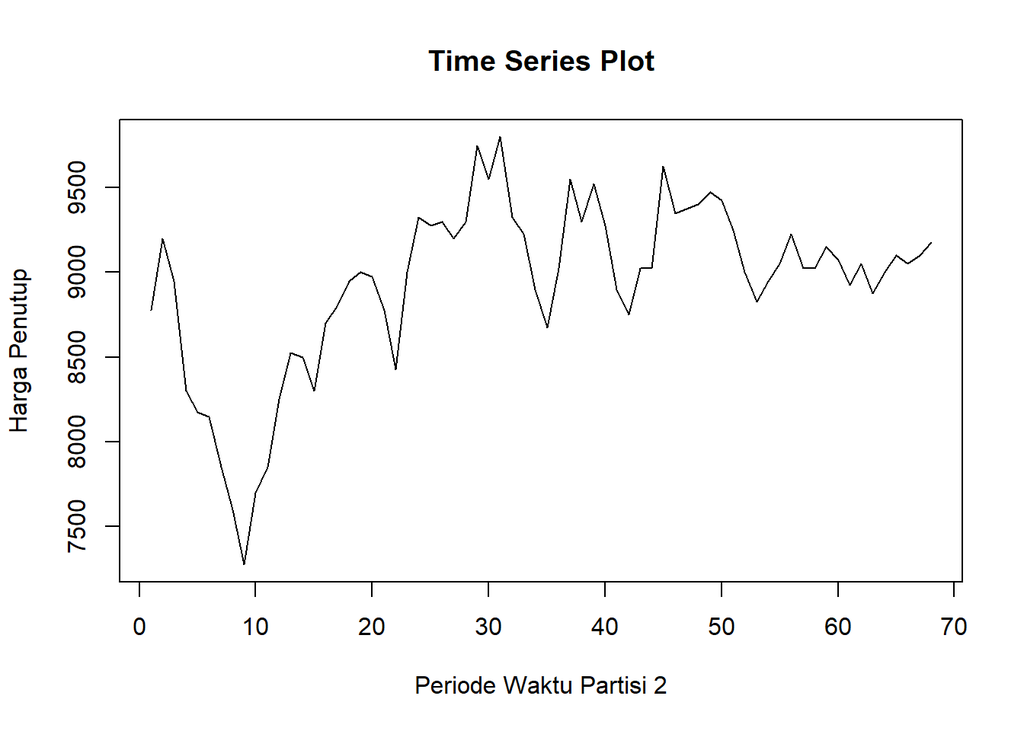

```r
ts.plot(data.ts2, xlab="Periode Waktu Partisi 2", ylab="Harga Penutup", main = "Time Series Plot")
```

Berdasarkan plot time series tersebut, terlihat bahwa data tidak stasioner dalam rataan karena masih terdapat tren pada data, dan tidak stasioner dalam ragam karena memiliki lebar pita yang cenderung tidak sama

#### Plot ACF

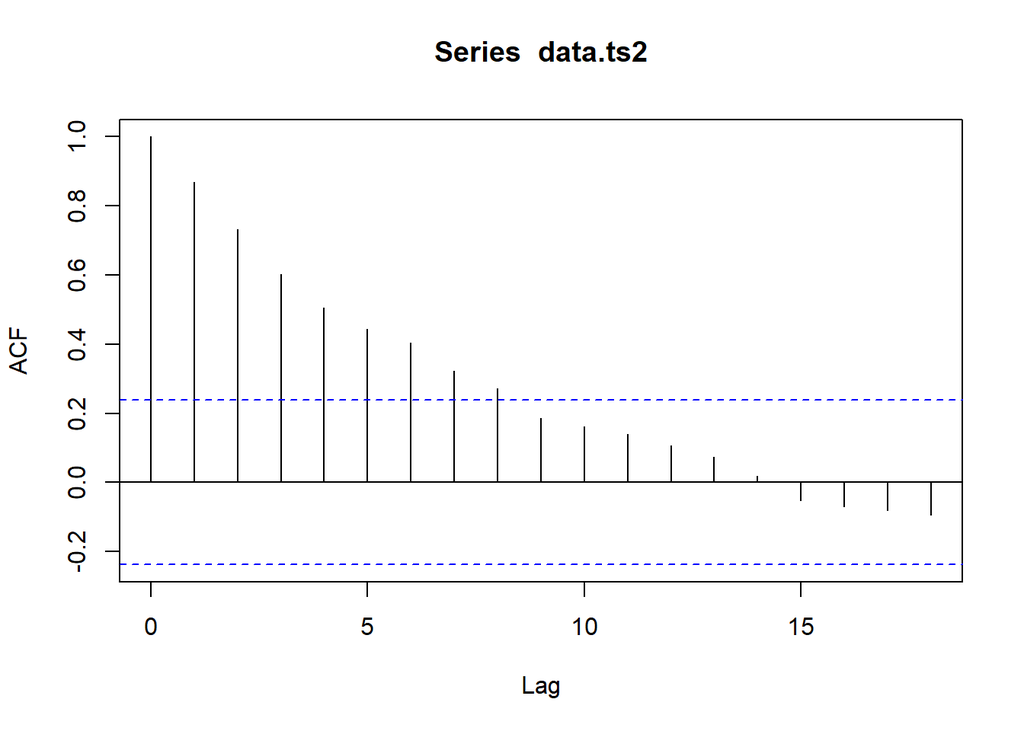

```r
acf(data.ts2)
```

Berdasarkan plot ACF, terlihat bahwa plot ACF pada data tersebut menurun secara perlahan (*tails off slowly*) yang menandakan data tidak stasioner dalam rataan

#### Uji ADF

```r
adf.test(data.ts2)
```

```
##
##  Augmented Dickey-Fuller Test
##
## data:  data.ts2
## Dickey-Fuller = -2.0401, Lag order = 4, p-value = 0.5588
## alternative hypothesis: stationary
```

$H_0$ : Data tidak stasioner dalam rataan

$H_1$ : Data stasioner dalam rataan

Berdasarkan uji ADF tersebut, didapat *p-value* sebesar 0.5588 yang lebih besar dari taraf nyata 5% dan menandakan bahwa data tidak stasioner dalam rataan. Hal ini sesuai dengan hasil eksplorasi menggunakan plot time series dan plot ACF